# Chapter2 part4

P.S.

2020-04-25

### 2.12 文本、字符串和模式匹配

在R中， 字符串由双引号定义：

```r
a <- "abc"
b <- "123"
c <- c(3,4,5)
```

数字可以强制转换为字符(如上文b所示)，但非数字字符不能强制转换为数字:

```r
as.character(c)
```

```
## [1] "3" "4" "5"
```

```r
as.numeric(a)
```

```
## [1] NA
```

```r
as.numeric(b)
```

```
## [1] 123
```

字符串最初令人困惑的事情之一是字符对象(向量)的长度与组成该对象的字符串中的字符数(nchar)之间的区别:

```r
pets <- c("cat","dog","gerbil","terrapin")
```

pets向量的长度：

```r
length(pets)
```

```
## [1] 4
```

字符串的长度：

```r
nchar(pets)
```

```
## [1] 3 3 6 8
```

R中有两个内置的向量，包含26个字母的小写(letters)和大写(LETTERS):

```r
letters
```

```
##  [1] "a" "b" "c" "d" "e" "f" "g" "h" "i" "j" "k" "l" "m" "n" "o" "p" "q" "r" "s"
## [20] "t" "u" "v" "w" "x" "y" "z"
```

```r
LETTERS
```

```
##  [1] "A" "B" "C" "D" "E" "F" "G" "H" "I" "J" "K" "L" "M" "N" "O" "P" "Q" "R" "S"
## [20] "T" "U" "V" "W" "X" "Y" "Z"
```

要找出字母n是向量中的第多少个元素，可以使用which函数:

```r
which(letters=="n")
```

```
## [1] 14
```

如果想要字符向量没有引号，可以使用noquote函数：

```r
noquote(letters)
```

```
##  [1] a b c d e f g h i j k l m n o p q r s t u v w x y z
```

#### 2.12.1 将字符串粘贴在一起

可以把个别字符串合并成字符向量:

```r
c(a,b)
```

```
## [1] "abc" "123"
```

如何想将两个字符串合并在一起，可以使用paste函数：

```r
paste(a,b,sep="")
```

```
## [1] "abc123"
```

第三个参数sep=""，表示将两个字符串粘贴在一起，中间不需要任何分隔符。paste的默认方式是插入一个空格:

```r
paste(a,b)
```

```
## [1] "abc 123"
```

注意，在粘贴中使用sep=""选项时，不会丢失字符串中的空格。

```r
paste(a,b," a longer phrase containing blanks",sep="")
```

```
## [1] "abc123 a longer phrase containing blanks"
```

如果要粘贴的参数之一是向量，则将向量的每个元素粘贴到指定的字符串中，以生成相同长度的对象:

```r
d <- c(a,b,"new")
e <- paste(d,"a longer phrase containing blanks")
e
```

```
## [1] "abc a longer phrase containing blanks"
## [2] "123 a longer phrase containing blanks"
## [3] "new a longer phrase containing blanks"
```

paste函数有很多用处，比如说，我们在批量的读取网页时：

```r
myurl <- paste("http://journal.psych.ac.cn/xlxb/CN/10.3724/SP.J.1041.2018.0", 1,2,2,4, sep = "")
```

#### 2.12.2 提取字符串

首先，我们假设有一条短信：

```r
phrase <- "the quick brown fox jumps over the lazy dog"
```

substr的函数用于从字符串中提取指定数量字符的子字符串。我们用一个循环的形式来说明它的用法：

```r
q <- character(20)
for (i in 1:20) q[i] <- substr(phrase,1,i)
q
```

```
##  [1] "t"                    "th"                   "the"
##  [4] "the "                 "the q"                "the qu"
##  [7] "the qui"              "the quic"             "the quick"
## [10] "the quick "           "the quick b"          "the quick br"
## [13] "the quick bro"        "the quick brow"       "the quick brown"
## [16] "the quick brown "     "the quick brown f"    "the quick brown fo"
## [19] "the quick brown fox"  "the quick brown fox "
```

substr中的第二个参数是提取开始的地方(在本例中始终是第一个字符)，第三个参数是提取结束的地方(在本例中是第i个)。

#### 2.12.3 在字符串中计数

计算字符串中的字符总数再简单不过了;直接使用nchar函数:

```r
nchar(phrase)
```

```
## [1] 43
```

为了搞清楚具体是哪些字符，需要将字符串分割成独立字符(43个字符)，使用strsplit如下:

```r
strsplit(phrase,split=character(0))
```

```
## [[1]]
##  [1] "t" "h" "e" " " "q" "u" "i" "c" "k" " " "b" "r" "o" "w" "n" " " "f" "o" "x"
## [20] " " "j" "u" "m" "p" "s" " " "o" "v" "e" "r" " " "t" "h" "e" " " "l" "a" "z"
## [39] "y" " " "d" "o" "g"
```

还可以计算，每个字符被使用了几次：

```r
table(strsplit(phrase,split=character(0)))
```

```
##
##   a b c d e f g h i j k l m n o p q r s t u v w x y z
## 8 1 1 1 1 3 1 1 2 1 1 1 1 1 1 4 1 1 2 1 2 2 1 1 1 1 1
```

结果表明，所有的字母在我们的短信中至少使用了一次，而在称为短信的字符串中有8个空格。还可以通过这一现象来计算句子中的单词数（因为2个单词之间有1个空格，3个单词之间有2个空格，以此类推）：

```r
words <- 1+table(strsplit(phrase,split=character(0)))[1]
words
```

```
##
## 9
```

还可以使用strsplit函数将字符串分开，例如，可以按空格将短信中的单词分开：

```r
strsplit(phrase, " ")
```

```
## [[1]]
## [1] "the"   "quick" "brown" "fox"   "jumps" "over"  "the"   "lazy"  "dog"
```

```r
table(lapply(strsplit(phrase, " "), nchar))
```

```
##
## 3 4 5
## 4 2 3
```

一共有4个三字母单词，2个四字母单词，3个五字母单词。

综合上述的函数，我们还可以将句子完全翻过来，加上rev函数：

```r
strsplit(phrase,NULL)
```

```
## [[1]]
##  [1] "t" "h" "e" " " "q" "u" "i" "c" "k" " " "b" "r" "o" "w" "n" " " "f" "o" "x"
## [20] " " "j" "u" "m" "p" "s" " " "o" "v" "e" "r" " " "t" "h" "e" " " "l" "a" "z"
## [39] "y" " " "d" "o" "g"
```

```r
lapply(strsplit(phrase,NULL),rev)
```

```
## [[1]]
##  [1] "g" "o" "d" " " "y" "z" "a" "l" " " "e" "h" "t" " " "r" "e" "v" "o" " " "s"
## [20] "p" "m" "u" "j" " " "x" "o" "f" " " "n" "w" "o" "r" "b" " " "k" "c" "i" "u"
## [39] "q" " " "e" "h" "t"
```

```r
sapply(lapply(strsplit(phrase, NULL), rev), paste, collapse="")
```

```
## [1] "god yzal eht revo spmuj xof nworb kciuq eht"
```

要将答案还原为单个字符串，需要使用collapse参数。

当我们指定一个特定的字符串(如the)来构成分割的基础时，我们最终得到一个由不包含指定字符串（the）的列表。

```r
strsplit(phrase,"the")
```

```
## [[1]]
## [1] ""                             " quick brown fox jumps over "
## [3] " lazy dog"
```

#### 2.12.4 文本大小写

使用toupper和tolower功能，可以轻松切换大小写:

```r
toupper(phrase)
```

```
## [1] "THE QUICK BROWN FOX JUMPS OVER THE LAZY DOG"
```

```r
tolower(toupper(phrase))
```

```
## [1] "the quick brown fox jumps over the lazy dog"
```

#### 2.12.5 match函数和关系数据库

match函数回答了以下问题:第二个向量中的值在第一个向量中出现(如果有的话)在哪里?它是一个非常重要的函数.

```r
first <- c(5,8,3,5,3,6,4,4,2,8,8,8,4,4,6)
second <- c(8,6,4,2)
match(first,second)
```

```
##  [1] NA  1 NA NA NA  2  3  3  4  1  1  1  3  3  2
```

match生成一个下标向量(索引值)，这些下标是第二个向量中的下标。如果第一个向量的元素不出现在第二个向量的任何地方，则会返回NA。

#### 2.12.6 模式匹配

我们需要一个包含大量文本的dataframe，以使练习:

```r
wf <- read.table("D:/future_plan/group_learning/Dataset/worldfloras.txt",header=T,stringsAsFactors = F)
attach(wf)
names(wf)
```

```
## [1] "Country"    "Latitude"   "Area"       "Population" "Flora"
## [6] "Endemism"   "Continent"
```

```r
Country
```

```
##   [1] "Afghanistan"              "Albania"
##   [3] "Algeria"                  "Andorra"
##   [5] "Angola"                   "Antarctica"
##   [7] "Argentina"                "Australia"
##   [9] "Austria"                  "Bahrain"
##  [11] "Balearic Islands"         "Bangladesh"
##  [13] "Belgium"                  "Belize"
##  [15] "Benin"                    "Bhutan"
##  [17] "Bolivia"                  "Botswana"
##  [19] "Brazil"                   "Brunei"
##  [21] "Bulgaria"                 "Burkina Faso"
##  [23] "Burma"                    "Burundi"
##  [25] "Cameroon"                 "Canada"
##  [27] "Central African Republic" "Chad"
##  [29] "Chile"                    "China"
```

[output cut: 66 more lines]

我们可以使用grep函数来取出带有某个字母或字符的国家名称。

```r
Country[grep("R",Country)]
```

```
## [1] "Central African Republic" "Costa Rica"
## [3] "Dominican Republic"       "Puerto Rico"
## [5] "Reunion"                  "Romania"
## [7] "Rwanda"                   "USSR"
```

若要将搜索限制以R开头的国家，可使用^字符：

```r
Country[grep("^R",Country)]
```

```
## [1] "Reunion" "Romania" "Rwanda"
```

若要选择国家名称包括多个单词且大写R作为其第二个或后续名称的首字母的国家，我们将字符串指定为blank+R:

```r
Country[grep(" R",Country)]
```

```
## [1] "Central African Republic" "Costa Rica"
## [3] "Dominican Republic"       "Puerto Rico"
```

要找到所有有两个或两个以上名字的国家，只需搜索一个空白的""：

```r
Country[grep(" ",Country)]
```

```
##  [1] "Balearic Islands"         "Burkina Faso"
##  [3] "Central African Republic" "Costa Rica"
##  [5] "Dominican Republic"       "El Salvador"
##  [7] "French Guiana"            "Germany East"
##  [9] "Germany West"             "Hong Kong"
## [11] "Ivory Coast"              "New Caledonia"
## [13] "New Zealand"              "Papua New Guinea"
## [15] "Puerto Rico"              "Saudi Arabia"
## [17] "Sierra Leone"             "Solomon Islands"
## [19] "South Africa"             "Sri Lanka"
## [21] "Trinidad & Tobago"        "Tristan da Cunha"
## [23] "United Kingdom"           "Viet Nam"
## [25] "Yemen North"              "Yemen South"
```

要查找名称以“y”结尾的国家，用$符号:

```r
Country[grep("y$",Country)]
```

```
## [1] "Hungary"  "Italy"    "Norway"   "Paraguay" "Sicily"   "Turkey"   "Uruguay"
```

还可以匹配包括某个字母或数据的字符：

```r
Country[grep("[C-E]",Country)]
```

```
##  [1] "Cameroon"                 "Canada"
##  [3] "Central African Republic" "Chad"
##  [5] "Chile"                    "China"
##  [7] "Colombia"                 "Congo"
##  [9] "Corsica"                  "Costa Rica"
## [11] "Crete"                    "Cuba"
## [13] "Cyprus"                   "Czechoslovakia"
## [15] "Denmark"                  "Dominican Republic"
## [17] "Ecuador"                  "Egypt"
## [19] "El Salvador"              "Ethiopia"
## [21] "Germany East"             "Ivory Coast"
## [23] "New Caledonia"            "Tristan da Cunha"
```

```r
#以C-E为首字母的国家名
Country[grep("^[C-E]",Country)]
```

```
##  [1] "Cameroon"                 "Canada"
##  [3] "Central African Republic" "Chad"
##  [5] "Chile"                    "China"
##  [7] "Colombia"                 "Congo"
##  [9] "Corsica"                  "Costa Rica"
## [11] "Crete"                    "Cuba"
## [13] "Cyprus"                   "Czechoslovakia"
## [15] "Denmark"                  "Dominican Republic"
## [17] "Ecuador"                  "Egypt"
## [19] "El Salvador"              "Ethiopia"
```

```r
#所有不是以a-t为结束字母的国家名
Country[-grep("[a-t]$",Country)]
```

```
##  [1] "Hungary"  "Italy"    "Norway"   "Paraguay" "Peru"     "Sicily"
##  [7] "Turkey"   "Uruguay"  "USA"      "USSR"     "Vanuatu"
```

#### 2.12.7 .作为任意字符

```r
Country[grep("^.y",Country)]
```

```
## [1] "Cyprus" "Syria"
```

```r
#y作为第三个字母
Country[grep("^..y",Country)]
```

```
## [1] "Egypt"      "Guyana"     "Seychelles"
```

```r
#y作为第六个字母
Country[grep("^.{5}y",Country)]
```

```
## [1] "Norway" "Sicily" "Turkey"
```

#### 2.12.8 替换字符串中的文本

在R中使用sub和gsub函数进行搜索和替换操作。它们的区别在于sub只修改文本中的第一个相关字符，而gsub则修改所有的。

```r
text <- c("arm", "leg", "head", "foot", "hand", "hindleg","elbow")

#将所有的小写h修改为H
gsub("h","H",text)
```

```
## [1] "arm"     "leg"     "Head"    "foot"    "Hand"    "Hindleg" "elbow"
```

```r
#使用sub修改
sub("o","O",text)
```

```
## [1] "arm"     "leg"     "head"    "fOot"    "hand"    "hindleg" "elbOw"
```

另外，还可以向之前一样指定修改的模式

```r
#不管以任务字母开头的都修改为大写字线O
gsub("ˆ.","O",text)
```

```
## [1] "arm"     "leg"     "head"    "foot"    "hand"    "hindleg" "elbow"
```

```r
#将所有的字符都改为大写
gsub("(\\w*)", "\\U\\1",text, perl=TRUE)
```

```
## [1] "ARM"     "LEG"     "HEAD"    "FOOT"    "HAND"    "HINDLEG" "ELBOW"
```

```r
gsub("(^\\w)","\\U\\1",text, perl=TRUE)
```

```
## [1] "Arm"     "Leg"     "Head"    "Foot"    "Hand"    "Hindleg" "Elbow"
```

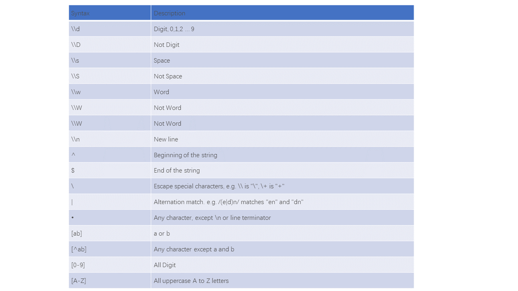

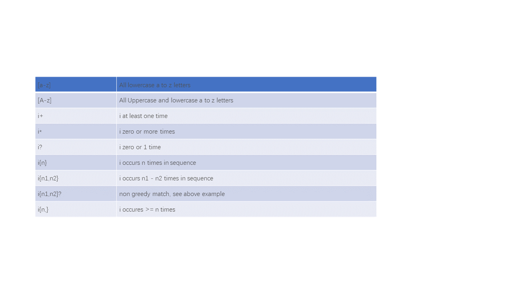

#### 2.12.9 使用regexpr在向量中定位模式

我们可能想知道某个字符是否出现在字符串中，如果是，它出现在哪里。因此，regexpr的结果是一个数值向量(与上面的grep一样)。如果模式没有出现在字符串中，则regexpr返回的默认值为-1：

```r
regexpr("o",text)
```

```
## [1] -1 -1 -1  2 -1 -1  4
## attr(,"match.length")
## [1] -1 -1 -1  1 -1 -1  1
## attr(,"index.type")
## [1] "chars"
## attr(,"useBytes")
## [1] TRUE
```

```r
freq <- as.vector(unlist(lapply(gregexpr("o",text),length)))
present <- ifelse(regexpr("o",text)<0,0,1)
freq*present
```

```
## [1] 0 0 0 2 0 0 1
```

#### 2.12.10 使用%in%和which

如果想要了解两个字符向量之间的匹配：

```r
stock <- c("car","van")
requests <- c("truck","suv","van","sports","car","waggon","car")

which(requests %in% stock)
```

```
## [1] 3 5 7
```

如果想要了解具体是匹配的哪个字符：

```r
requests [which(requests %in% stock)]
```

```
## [1] "van" "car" "car"
```